# 1.1 Feature Extraction

ORB-SLAM3 — Visuelle Merkmale erkennen und beschreiben

Nediljko Andrijanic

2026-05-30

# Schritt 1: Graustufen

## Warum nur Helligkeit, nicht Farbe?

- **Farbe ändert sich mit Beleuchtung:** Ein rotes Objekt kann dunkelrot oder hellrot sein — die Form ist aber gleich
- **Kanten sind Helligkeitsunterschiede:** Ein dunkler Bereich neben einem hellen Bereich erzeugt eine Kante — egal welche Farben
- **Computer Vision braucht Struktur, nicht Farbe:** Features sind geometrische Muster (Ecken, Kanten, Gradienten)
- **Rechenzeit sparen:** 3 Kanäle (RGB) → 1 Kanal (Gray) = 3× schneller

## Die Formel

$$I_{grau} = 0.299 \cdot R + 0.587 \cdot G + 0.114 \cdot B$$

**Warum Grün am stärksten?** Das menschliche Auge ist dafür am empfindlichsten.

## Beispiel: RGB → Graustufen

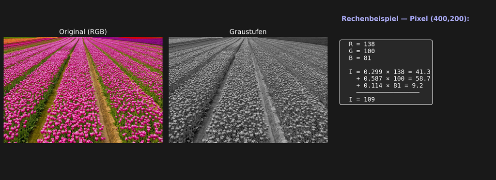

# Schritt 2: Gauss-Filter

## 2.1 Was macht Filter?

**Problem:** Kamerasensoren erzeugen Rauschen — zufällige Helligkeits-Schwankungen

**Lösung:** Jeder Pixel bekommt einen neuen Wert = **gewichteter Durchschnitt** seiner Nachbarn

- Nachbar-Pixel in der **Nähe** zählen mehr
- Nachbar-Pixel weit weg zählen weniger
- Rauschen wird geglättet
- Echte Kanten bleiben erhalten

## 2.2 Wie berechnet man?

**Gauss-Formel:**

$$G(x,y) = \frac{1}{2\pi\sigma^2} e^{-\frac{x^2+y^2}{2\sigma^2}}$$

**Was sind x und y?** — Die **Koordinaten relativ zur Mitte** des 5×5 Kernels:

```
      x →  -2   -1    0   +1   +2
           ┌────┬────┬────┬────┬────┐
      y -2 │    │    │    │    │    │
           ├────┼────┼────┼────┼────┤
      y -1 │    │    │    │    │    │
           ├────┼────┼────┼────┼────┤
      y  0 │    │    │ M  │    │    │  ← Center (x=0, y=0)
           ├────┼────┼────┼────┼────┤
      y +1 │    │    │    │    │    │
           ├────┼────┼────┼────┼────┤
      y +2 │    │    │    │    │    │
           └────┴────┴────┴────┴────┘
```

## Gewichte — je weiter weg, desto kleiner

[output not shown]

Die Gewichte addieren sich zu **1.0**.

## 2.3 Was ist das Ergebnis?

**Vorher und Nachher:**

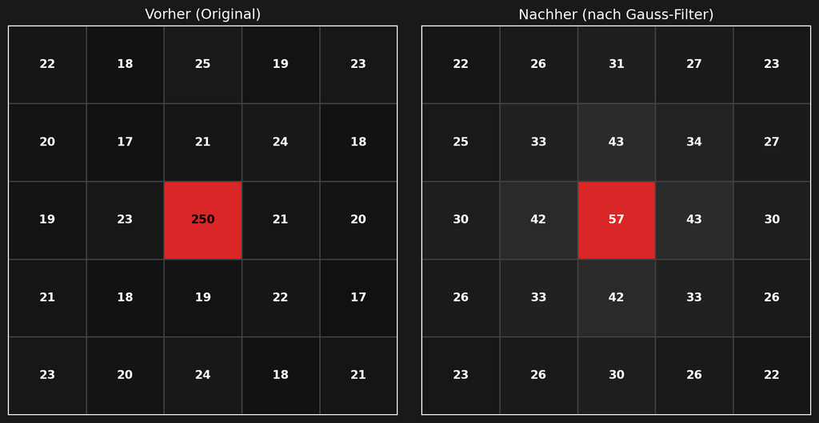

# Schritt 3: Bildpyramide

## Problem: Objekte in verschiedenen Größen

**Beispiel:** - Eine Straßenlaterne **2m** entfernt → groß im Bild - Dieselbe Laterne **10m** entfernt → klein im Bild

→ ORB ohne Pyramide würde **dieselbe Laterne nicht wiedererkennen**.

## Die Lösung — 8 Größenstufen

| Stufe | Faktor | Beispiel |
| --- | --- | --- |
| 0 | 1.0× | 800×400 |
| 1 | 0.83× | 667×333 |
| 3 | 0.58× | 463×231 |
| 7 | 0.28× | 223×111 |

Features auf Stufe 3 entsprechen Objekten die **1.73× kleiner** erscheinen.

## Alle 8 Stufen mit Features

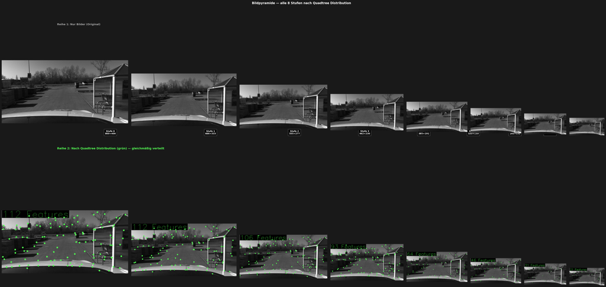

## Wie funktioniert die Pyramide?

- **Stufe 0:** Original-Größe (z.B. 800×400 px)
- **Stufe 1:** 1.2× verkleinert → 667×333 px
- **Stufe 2:** 1.2× verkleinert → 556×278 px
- **…**
- **Stufe 7:** Nach 7 Verkleinerungen → 223×111 px

Jede Stufe ist **exakt 1.2× kleiner**. Dadurch findet FAST **unterschiedliche Objekt-Größen** auf unterschiedlichen Stufen!

## Sub-Pixel Genauigkeit

Ein Feature auf Stufe $k$ wird auf Original-Koordinaten zurückgerechnet:

$$\text{Position}_\text{original} = \text{Position}_\text{Stufe k} \times 1.2^k$$

[output not shown]

# Schritt 4: FAST Detektor

## Ziel: Ecken erkennen

Eine **Ecke** ist ein Punkt, wo sich Helligkeit abrupt in **zwei Richtungen** ändert.

## FAST Algorithmus

**Für jeden Pixel p:**

1. Zeichne einen **Kreis mit 16 Nachbarn** (Radius 3)
2. Prüfe ob ≥ **9 zusammenhängende** Pixel entweder:
   - **Heller** sind: $I_x > I_p + t$
   - **Dunkler** sind: $I_x < I_p - t$
3. Falls ja → **Ecke erkannt**

$t$ = Schwellenwert (z.B. 5 oder 20)

## Die 16-er Kreis-Maske

```
     ×  ×  ×
   ×  1  2  3  ×
  × 16        4 ×
  × 15    p   5 ×    ← Zentrum p
  × 14        6 ×
   × 13  8  7  ×
     × 12 11 10 9 ×

Wenn z.B. Pixel 1–10 alle
dunkler als p−t sind:
→ 10 zusammenhängende
→ ECKE!
```

**Warum 9?** Mindestens die Hälfte+1 des Kreises (16/2 + 1 = 9) muss konsistent sein.

## Beispiel: Pixel-Grid

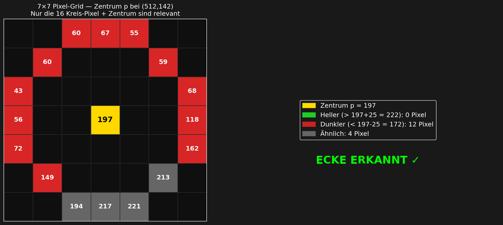

## Schritt 6: Quadtree-Verteilung

**Problemstellung:** Features sind an bestimmten Stellen konzentriert (besonders an Kanten). Wir benötigen eine gleichmäßigere Verteilung.

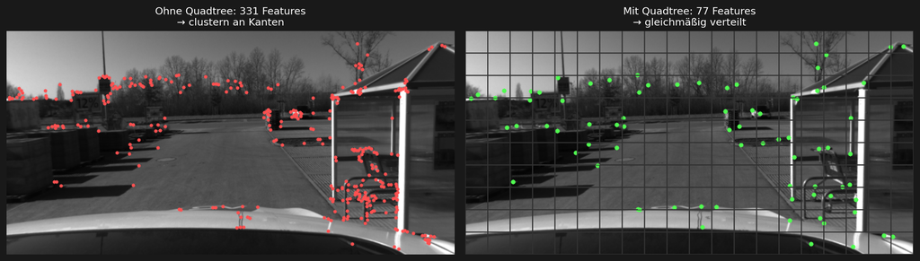

*Matplotlib-Visualisierung: Quadtree-Verteilung*

## Schritt 7: Harris Corner Score

**Harris Corner Detector:** Während FAST sehr schnell ist, ist Harris robuster gegen Rotation und Skalierung.

**Harris Response Formula:** R = det(M) − k·trace(M)² mit M = Sobel Gradient Matrix

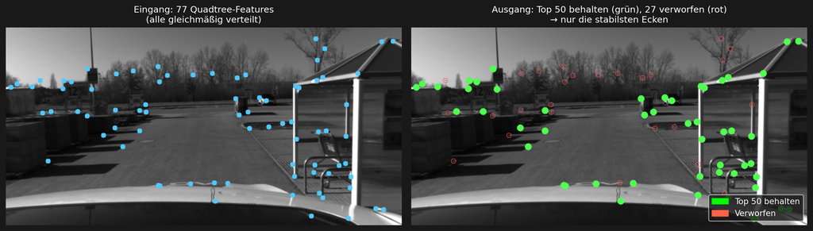

*Matplotlib-Visualisierung: Harris Corner Detection*

# Zusammenfassung

## Die Pipeline in Schritt 1-4

1. **Graustufen:** RGB → Helligkeit (1 Kanal statt 3)
2. **Gauss-Filter:** Rauschen reduzieren mit gewichteten Durchschnitt
3. **Bildpyramide:** 8 Größenstufen für Skalierungsinvarianz
4. **FAST Detektor:** Ecken erkennen auf allen Stufen

## Ergebnis

✅ **Viele Keypoints** mit Position (x, y) auf allen 8 Pyramidenstufen

Die werden dann weiterverarbeitet für: - Orientierung bestimmen - Deskriptoren berechnen - Matching mit anderen Bildern - Pose-Schätzung - Trajektorie-Verfolgung